# Homework Assignment 1

Edward Jerse

Assigned: Oct 24, 2020, Due Sun Nov 01, 2020 11:59PM

## Data frame basics

We will continue working with the nycflights dataset we looked at in class. **Please be sure to keep the data file in the same directory as the RMD file - your project directory.**

First - make sure that you are reading the data correctly and doing all the data cleaning steps that we did in class. Feel free to go beyond our class work in cleaning the data if you feel the need.

I now would like you to answer the following - all in their own separate R code blocks.

```r
#Read in the dataset
nyc <- read.csv("nycflights.csv")

# Deleting the column X
nyc$X <- NULL

# Factorize necessary columns
nyc$origin <- as.factor(nyc$origin)
nyc$tailnum <- as.factor(nyc$tailnum)
nyc$month <- as.factor(nyc$month)
nyc$dest <- as.factor(nyc$dest)
nyc$carrier <- as.factor(nyc$carrier)
nyc$flight <- as.factor(nyc$flight)

str(nyc)
```

```
## 'data.frame':    336776 obs. of  19 variables:
##  $ year          : int  2013 2013 2013 2013 2013 2013 2013 2013 2013 2013 ...
##  $ month         : Factor w/ 12 levels "1","2","3","4",..: 1 1 1 1 1 1 1 1 1 1 ...
##  $ day           : int  1 1 1 1 1 1 1 1 1 1 ...
##  $ dep_time      : int  517 533 542 544 554 554 555 557 557 558 ...
##  $ sched_dep_time: int  515 529 540 545 600 558 600 600 600 600 ...
##  $ dep_delay     : int  2 4 2 -1 -6 -4 -5 -3 -3 -2 ...
##  $ arr_time      : int  830 850 923 1004 812 740 913 709 838 753 ...
##  $ sched_arr_time: int  819 830 850 1022 837 728 854 723 846 745 ...
##  $ arr_delay     : int  11 20 33 -18 -25 12 19 -14 -8 8 ...
##  $ carrier       : Factor w/ 16 levels "9E","AA","AS",..: 12 12 2 4 5 12 4 6 4 2 ...
##  $ flight        : Factor w/ 3844 levels "1","2","3","4",..: 1382 1545 1042 677 425 1527 469 3700 69 266 ...
##  $ tailnum       : Factor w/ 4043 levels "D942DN","N0EGMQ",..: 180 524 2401 3204 2661 1142 1829 3300 2207 1178 ...
##  $ origin        : Factor w/ 3 levels "EWR","JFK","LGA": 1 3 2 2 3 1 1 3 2 3 ...
##  $ dest          : Factor w/ 105 levels "ABQ","ACK","ALB",..: 44 44 59 13 5 70 36 43 55 70 ...
##  $ air_time      : int  227 227 160 183 116 150 158 53 140 138 ...
##  $ distance      : int  1400 1416 1089 1576 762 719 1065 229 944 733 ...
##  $ hour          : int  5 5 5 5 6 5 6 6 6 6 ...
##  $ minute        : int  15 29 40 45 0 58 0 0 0 0 ...
##  $ time_hour     : Factor w/ 6936 levels "2013-01-01 05:00:00",..: 1 1 1 1 2 1 2 2 2 2 ...
```

### Data Exploration

How many airlines are there? (Hint: levels and length can be useful here)

```r
length(levels(nyc$carrier))
```

```
## [1] 16
```

How many flights there were by the airline with code OO? (Hint: nrow can be useful here along with logical indexing)

```r
AirDoubleZero <- nyc[nyc$carrier == "OO", ]
nrow(AirDoubleZero)
```

```
## [1] 32
```

How long is the shortest flight out of any NYC airport? (Hint: min can be useful, remember to handle NA values)

```r
min(nyc$air_time, na.rm = TRUE)
```

```
## [1] 20
```

How many flights were there by United Airlines (code: UA) on Jan 12th 2013?

```r
UAJAN12 <- nyc[nyc$carrier == "UA" & nyc$time_hour == "2013-01-12", ]
UAJAN12 <- nyc[nyc$carrier == "UA" & nyc$year == 2013 & nyc$day == 12 & nyc$month == 1, ]
nrow(UAJAN12)
```

```
## [1] 112
```

### Arrival Delay

Lets focus on Arrival Delay.

What was the average arrival delay for all airports and all airlines combined in Jan 2013?

```r
nycjan <- nyc[nyc$month == 1, ]
mean(nycjan$arr_delay, na.rm = T)
```

```
## [1] 6.129972
```

Whats was the median arrival delay for all airports and all airlines combined in Jan 2013

```r
median(nycjan$arr_delay, na.rm = T)
```

```
## [1] -3
```

Based on your answers to the two questions above, what can you say about the distribution of arrival delays? Provide your answer in a text paragraph form.

This is a right skewed data set becasue the mean is greater than the median

### Airline Performance

Lets see if all airlines are equally terrible as far as flight arrival delays are concerned. For this question you will have to make sure that airline column is coded as a factor.

Calculate average arrival delays by airline (Hint: look up the command `tapply`)

```r
delay_by_airline <- tapply(nyc$dep_delay, nyc$carrier, mean, na.rm = TRUE)
delay_by_airline
```

```
##        9E        AA        AS        B6        DL        EV        F9        FL
## 16.725769  8.586016  5.804775 13.022522  9.264505 19.955390 20.215543 18.726075
##        HA        MQ        OO        UA        US        VX        WN        YV
##  4.900585 10.552041 12.586207 12.106073  3.782418 12.869421 17.711744 18.996330
```

Draw a Bar Plot of Average Arrival Delays for all the Airlines (Hint: command for making a Bar Plot is simply barplot)

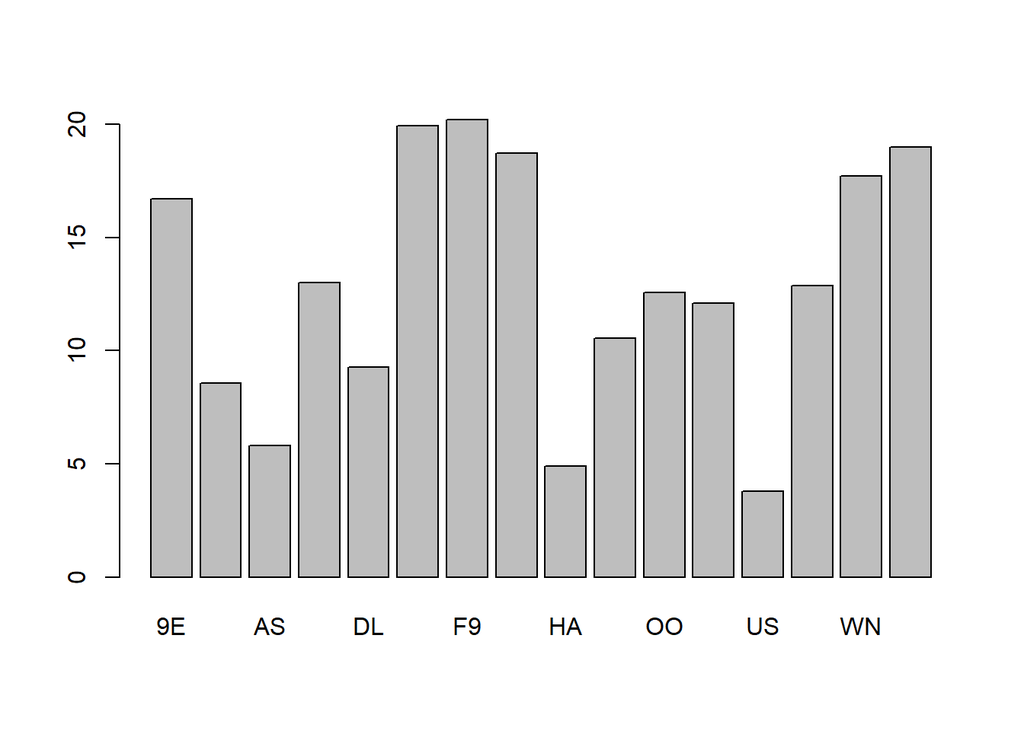

```r
barplot(delay_by_airline)
```

```r
neg_delay_by_airline <- nyc[delay_by_airline < 0, ]
```

### Air Gain

We now want to know whether airlines actually make up time when on air.

Create a new column named airgain such that airgain = (departure delay - arrival delay) : this is the amount of delay a flight made up while in air.

```r
nyc$airgain <- (nyc$dep_delay - nyc$arr_delay)
```

1. Explore airgain data - calculate suitable descriptive statistics and appropriate graphics to better understand this data. This part is open ended - you do what you feel works best for you.

```r
-#Mean Airgain
round(mean(nyc$airgain, na.rm = TRUE), 2)
```

```
## [1] -5.66
```

```r
#Median Airgain
round(median(nyc$airgain, na.rm = TRUE), 2)
```

```
## [1] 7
```

```r
#Max Airgain
round(max(nyc$airgain, na.rm = TRUE), 2)
```

```
## [1] 109
```

```r
#Min Airgain
round(min(nyc$airgain, na.rm = TRUE), 2)
```

```
## [1] -196
```

2. Answer the questions:

Do airlines actually gain any time when in air on average?

```r
mean(nyc$airgain, na.rm = T)
```

```
## [1] 5.659779
```

Based on the calculation (i.e., because it is a positive number), it appears that airlines do gain time on average.

Calculate average airgain for different airlines - which airlines do a better job, which do a worse job?

```r
airgain_by_airline <- tapply(nyc$airgain, nyc$carrier, mean, na.rm = TRUE)
airgain_by_airline
```

```
##         9E         AA         AS         B6         DL         EV         F9
##  9.0599052  8.2048393 15.7616361  3.5095746  7.5796089  4.0424982 -1.7195301
##         FL         HA         MQ         OO         UA         US         VX
## -1.5099213 11.8157895 -0.3293526  0.6551724  8.4588972  1.6150976 10.9921814
##         WN         YV
##  8.0125374  3.3419118
```

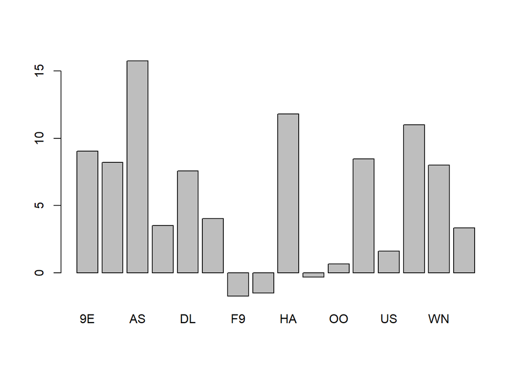

```r
barplot(airgain_by_airline)
```

F9, FL, MQ all lose time after taking off. 9E, AA, AS, B6, DL, EV, HA, OO, UA, US, VX, WN, YV all gain time after taking off.

### Merging Data Frames

> This section and the next is new compared to the class exercise. As you had an opportunity to work together in your breakout rooms for previous questions, this and the next section will carry a higher weight in grading for this HW.

You can get detailed information about the physical planes in our dataset in this file: `planes.csv`. Download and save this file in your project directory.

1. Read the `planes.csv` file using `read.csv` command. Do any data cleaning necessary.

```r
planes <- read.csv("planes.csv")
str(planes)
```

```
## 'data.frame':    3322 obs. of  10 variables:
##  $ X           : int  1 2 3 4 5 6 7 8 9 10 ...
##  $ tailnum     : Factor w/ 3322 levels "N10156","N102UW",..: 1 2 3 4 5 6 7 8 9 10 ...
##  $ year        : int  2004 1998 1999 1999 2002 1999 1999 1999 1999 1999 ...
##  $ type        : Factor w/ 3 levels "Fixed wing multi engine",..: 1 1 1 1 1 1 1 1 1 1 ...
##  $ manufacturer: Factor w/ 35 levels "AGUSTA SPA","AIRBUS",..: 18 3 3 3 18 3 3 3 3 3 ...
##  $ model       : Factor w/ 127 levels "150","172E","172M",..: 108 87 87 87 107 87 87 87 87 87 ...
##  $ engines     : int  2 2 2 2 2 2 2 2 2 2 ...
##  $ seats       : int  55 182 182 182 55 182 182 182 182 182 ...
##  $ speed       : int  NA NA NA NA NA NA NA NA NA NA ...
##  $ engine      : Factor w/ 6 levels "4 Cycle","Reciprocating",..: 3 3 3 3 3 3 3 3 3 3 ...
```

```r
summary(planes)
```

```
##        X             tailnum          year                            type
##  Min.   :   1.0   N10156 :   1   Min.   :1956   Fixed wing multi engine :3292
##  1st Qu.: 831.2   N102UW :   1   1st Qu.:1997   Fixed wing single engine:  25
##  Median :1661.5   N103US :   1   Median :2001   Rotorcraft              :   5
##  Mean   :1661.5   N104UW :   1   Mean   :2000
##  3rd Qu.:2491.8   N10575 :   1   3rd Qu.:2005
##  Max.   :3322.0   N105UW :   1   Max.   :2013
##                   (Other):3316   NA's   :70
##             manufacturer          model         engines          seats
##  BOEING           :1630   737-7H4    : 361   Min.   :1.000   Min.   :  2.0
##  AIRBUS INDUSTRIE : 400   A320-232   : 256   1st Qu.:2.000   1st Qu.:140.0
##  BOMBARDIER INC   : 368   CL-600-2B19: 171   Median :2.000   Median :149.0
##  AIRBUS           : 336   CL-600-2D24: 123   Mean   :1.995   Mean   :154.3
##  EMBRAER          : 299   737-824    : 122   3rd Qu.:2.000   3rd Qu.:182.0
##  MCDONNELL DOUGLAS: 120   MD-88      : 117   Max.   :4.000   Max.   :450.0
##  (Other)          : 169   (Other)    :2172
##      speed                 engine
##  Min.   : 90.0   4 Cycle      :   2
##  1st Qu.:107.5   Reciprocating:  28
##  Median :162.0   Turbo-fan    :2750
##  Mean   :236.8   Turbo-jet    : 535
##  3rd Qu.:432.0   Turbo-prop   :   2
##  Max.   :432.0   Turbo-shaft  :   5
##  NA's   :3299
```

```r
# Deleting the column X
planes$X <- NULL
```

2. Merge the flights data and the planes data using the `merge` command. You should do the merge on the common column named `tailnum`. *getting this right may need some trial and error and getting some help*.

```r
nyc_planes <- merge(nyc, planes, by="tailnum")
str(nyc_planes)
```

```
## 'data.frame':    284170 obs. of  28 variables:
##  $ tailnum       : Factor w/ 4043 levels "D942DN","N0EGMQ",..: 3 3 3 3 3 3 3 3 3 3 ...
##  $ year.x        : int  2013 2013 2013 2013 2013 2013 2013 2013 2013 2013 ...
##  $ month         : Factor w/ 12 levels "1","2","3","4",..: 8 1 1 1 2 9 3 3 11 6 ...
##  $ day           : int  12 17 23 10 17 23 12 20 3 11 ...
##  $ dep_time      : int  1312 1213 746 626 NA 1008 2000 2216 1218 1911 ...
##  $ sched_dep_time: int  1317 1218 645 630 1415 1015 2000 2100 1226 1911 ...
##  $ dep_delay     : int  -5 -5 61 -4 NA -7 0 76 -8 0 ...
##  $ arr_time      : int  1528 1422 852 802 NA 1117 2234 13 1404 2124 ...
##  $ sched_arr_time: int  1528 1415 757 800 1616 1139 2245 2315 1418 2115 ...
##  $ arr_delay     : int  0 7 55 2 NA -22 -11 58 -14 9 ...
##  $ carrier       : Factor w/ 16 levels "9E","AA","AS",..: 6 6 6 6 6 6 6 6 6 6 ...
##  $ flight        : Factor w/ 3844 levels "1","2","3","4",..: 2973 3253 2916 3186 2905 2864 2881 2628 3252 3052 ...
##  $ origin        : Factor w/ 3 levels "EWR","JFK","LGA": 1 1 1 1 1 1 1 1 1 1 ...
##  $ dest          : Factor w/ 105 levels "ABQ","ACK","ALB",..: 63 24 29 76 22 11 68 89 28 54 ...
##  $ air_time      : int  171 111 47 60 NA 105 193 101 92 157 ...
##  $ distance      : int  1167 529 199 319 628 748 1325 642 533 1092 ...
##  $ hour          : int  13 12 6 6 14 10 20 21 12 19 ...
##  $ minute        : int  17 18 45 30 15 15 0 0 26 11 ...
##  $ time_hour     : Factor w/ 6936 levels "2013-01-01 05:00:00",..: 4247 312 420 173 903 5042 1346 1499 5823 3074 ...
##  $ airgain       : int  -5 -12 6 -6 NA 15 11 18 6 -9 ...
##  $ year.y        : int  2004 2004 2004 2004 2004 2004 2004 2004 2004 2004 ...
##  $ type          : Factor w/ 3 levels "Fixed wing multi engine",..: 1 1 1 1 1 1 1 1 1 1 ...
##  $ manufacturer  : Factor w/ 35 levels "AGUSTA SPA","AIRBUS",..: 18 18 18 18 18 18 18 18 18 18 ...
##  $ model         : Factor w/ 127 levels "150","172E","172M",..: 108 108 108 108 108 108 108 108 108 108 ...
##  $ engines       : int  2 2 2 2 2 2 2 2 2 2 ...
##  $ seats         : int  55 55 55 55 55 55 55 55 55 55 ...
##  $ speed         : int  NA NA NA NA NA NA NA NA NA NA ...
##  $ engine        : Factor w/ 6 levels "4 Cycle","Reciprocating",..: 3 3 3 3 3 3 3 3 3 3 ...
```

```r
#Fix the two year columns to clarify the data
names(nyc_planes)[2] <- "year_departed"
names(nyc_planes)[20] <- "year_plane_created"
str(nyc_planes)
```

```
## 'data.frame':    284170 obs. of  28 variables:
##  $ tailnum           : Factor w/ 4043 levels "D942DN","N0EGMQ",..: 3 3 3 3 3 3 3 3 3 3 ...
##  $ year_departed     : int  2013 2013 2013 2013 2013 2013 2013 2013 2013 2013 ...
##  $ month             : Factor w/ 12 levels "1","2","3","4",..: 8 1 1 1 2 9 3 3 11 6 ...
##  $ day               : int  12 17 23 10 17 23 12 20 3 11 ...
##  $ dep_time          : int  1312 1213 746 626 NA 1008 2000 2216 1218 1911 ...
##  $ sched_dep_time    : int  1317 1218 645 630 1415 1015 2000 2100 1226 1911 ...
##  $ dep_delay         : int  -5 -5 61 -4 NA -7 0 76 -8 0 ...
##  $ arr_time          : int  1528 1422 852 802 NA 1117 2234 13 1404 2124 ...
##  $ sched_arr_time    : int  1528 1415 757 800 1616 1139 2245 2315 1418 2115 ...
##  $ arr_delay         : int  0 7 55 2 NA -22 -11 58 -14 9 ...
##  $ carrier           : Factor w/ 16 levels "9E","AA","AS",..: 6 6 6 6 6 6 6 6 6 6 ...
##  $ flight            : Factor w/ 3844 levels "1","2","3","4",..: 2973 3253 2916 3186 2905 2864 2881 2628 3252 3052 ...
##  $ origin            : Factor w/ 3 levels "EWR","JFK","LGA": 1 1 1 1 1 1 1 1 1 1 ...
##  $ dest              : Factor w/ 105 levels "ABQ","ACK","ALB",..: 63 24 29 76 22 11 68 89 28 54 ...
##  $ air_time          : int  171 111 47 60 NA 105 193 101 92 157 ...
##  $ distance          : int  1167 529 199 319 628 748 1325 642 533 1092 ...
##  $ hour              : int  13 12 6 6 14 10 20 21 12 19 ...
##  $ minute            : int  17 18 45 30 15 15 0 0 26 11 ...
##  $ time_hour         : Factor w/ 6936 levels "2013-01-01 05:00:00",..: 4247 312 420 173 903 5042 1346 1499 5823 3074 ...
##  $ year_plane_created: int  -5 -12 6 -6 NA 15 11 18 6 -9 ...
##  $ year.y            : int  2004 2004 2004 2004 2004 2004 2004 2004 2004 2004 ...
##  $ type              : Factor w/ 3 levels "Fixed wing multi engine",..: 1 1 1 1 1 1 1 1 1 1 ...
##  $ manufacturer      : Factor w/ 35 levels "AGUSTA SPA","AIRBUS",..: 18 18 18 18 18 18 18 18 18 18 ...
##  $ model             : Factor w/ 127 levels "150","172E","172M",..: 108 108 108 108 108 108 108 108 108 108 ...
##  $ engines           : int  2 2 2 2 2 2 2 2 2 2 ...
##  $ seats             : int  55 55 55 55 55 55 55 55 55 55 ...
##  $ speed             : int  NA NA NA NA NA NA NA NA NA NA ...
##  $ engine            : Factor w/ 6 levels "4 Cycle","Reciprocating",..: 3 3 3 3 3 3 3 3 3 3 ...
```

3. Now that you have a merged dataset, think of what interesting questions that you can ask that can be answered using the merged dataset. You are asked to pose five interesting questions and answer them. (For example: who are the top 10 manufacturers of planes that fly out of NYC airports?) **Be creative. Be bold. Ask questions that you would want to know answers to even if you were not doing this for a HW.**

Question 1: What is the average size of planes (measured by average number of seats) that fly out of each NYC airport?

```r
seat_size_by_origin <- tapply(nyc_planes$seats, nyc_planes$origin, mean, na.rm = TRUE)
seat_size_by_origin
```

```
##      EWR      JFK      LGA
## 125.7690 147.3740 140.1178
```

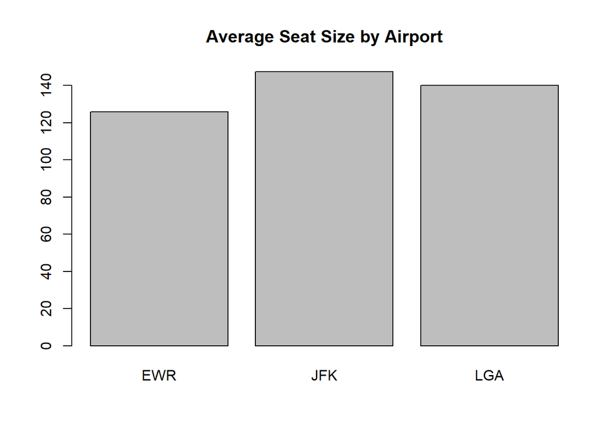

```
## numeric(0)
```

```r
barplot(seat_size_by_origin) + title("Average Seat Size by Airport")
```

Question 2: Identify the fastest model plane in the data set. What are the key NYC-origin routes flown by the fastest plane, listed with their maximum distance?

```r
max_speed_by_plane <- tapply(nyc_planes$speed, nyc_planes$model, max, na.rm = TRUE)
names(max_speed_by_plane[max_speed_by_plane == max(max_speed_by_plane)])
```

```
## [1] "DC-9-51"
```

The DC-9-51 is the fastest plane model.

```r
DC9_Flights <- nyc_planes[nyc_planes$model == "DC-9-51", ]
DC9_max_dist <- tapply(DC9_Flights$distance, DC9_Flights$dest, max, na.rm = TRUE)
DC9_max_dist <- as.data.frame(DC9_max_dist)
DC9_max_dist_clean <- na.omit(DC9_max_dist)
DC9_max_dist_clean
```

```
##     DC9_max_dist
## ATL          746
## DTW          488
```

Question 3: On average, are there signicant differences in average flight distance depending on the type of engine used?

```r
distance_by_engine <- tapply(nyc_planes$distance, nyc_planes$engine, mean, na.rm = TRUE)
distance_by_engine
```

```
##       4 Cycle Reciprocating     Turbo-fan     Turbo-jet    Turbo-prop
##     1325.6667     1090.8754      994.9219     1497.2671     1642.8936
##   Turbo-shaft
##     1362.4976
```

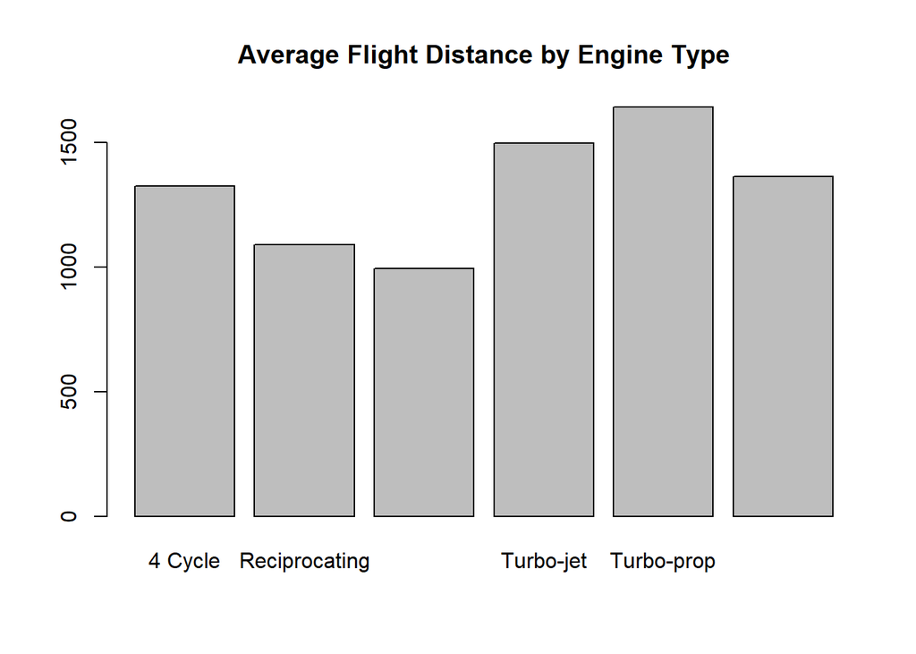

```
## numeric(0)
```

```r
barplot(distance_by_engine) + title("Average Flight Distance by Engine Type")
```

Question 4: Using a regression model, which variables are statistically significant in determining arrival delays?

```r
arrival_model <- lm(arr_delay ~ type + manufacturer + model + engines + seats + speed + engine, data=nyc_planes, na.action = na.omit)
summary(arrival_model)
```

```
##
## Call:
## lm(formula = arr_delay ~ type + manufacturer + model + engines +
##     seats + speed + engine, data = nyc_planes, na.action = na.omit)
##
## Residuals:
##    Min     1Q Median     3Q    Max
## -66.97 -22.79 -10.74   7.39 349.66
##
## Coefficients: (15 not defined because of singularities)
##                               Estimate Std. Error t value Pr(>|t|)
## (Intercept)                     4.0455     9.2135   0.439    0.661
## typeFixed wing single engine   -4.9770     8.9518  -0.556    0.578
## typeRotorcraft                 -4.2705    11.4708  -0.372    0.710
## manufacturerBELL                    NA         NA      NA       NA
## manufacturerCESSNA             15.0492    14.2001   1.060    0.290
## manufacturerDEHAVILLAND        -3.3636    13.9872  -0.240    0.810
## manufacturerDOUGLAS            -0.5455    13.0299  -0.042    0.967
## manufacturerMCDONNELL DOUGLAS  -1.7048    10.2670  -0.166    0.868
## manufacturerPIPER              -6.4343    10.9304  -0.589    0.556
## model172E                      -2.1176    13.8654  -0.153    0.879
## model172M                      -3.5040     8.8918  -0.394    0.694
## model172N                     -10.6667     6.9875  -1.527    0.127
## model206B                           NA         NA      NA       NA
## model310Q                     -21.3219    14.2001  -1.502    0.134
## model421C                     -14.2375    13.0427  -1.092    0.275
## model65-A90                         NA         NA      NA       NA
## modelA185F                     -0.1436     6.6861  -0.021    0.983
## modelDC-7BF                         NA         NA      NA       NA
## modelDC-9-51                        NA         NA      NA       NA
## modelOTTER DHC-3                    NA         NA      NA       NA
## modelPA-28-180                  5.7073     9.5447   0.598    0.550
## modelPA-31-350                      NA         NA      NA       NA
## modelPA-32R-300                     NA         NA      NA       NA
## engines                             NA         NA      NA       NA
## seats                               NA         NA      NA       NA
## speed                               NA         NA      NA       NA
## engineReciprocating                 NA         NA      NA       NA
## engineTurbo-jet                     NA         NA      NA       NA
## engineTurbo-prop                    NA         NA      NA       NA
## engineTurbo-shaft                   NA         NA      NA       NA
##
## Residual standard error: 43.22 on 905 degrees of freedom
##   (283250 observations deleted due to missingness)
## Multiple R-squared:  0.02559,    Adjusted R-squared:  0.01052
## F-statistic: 1.698 on 14 and 905 DF,  p-value: 0.05091
```

Unfortunately, due to complications from missing data/NA values, many variables are ‘not defined because of singularities.’ Of the remaining variables, none appear to be statistically significant at even a 10% significance level.

Question 5: How many available plane seats fly out of each airport each month?

```r
nyc_planes_jan <- nyc_planes[nyc_planes$month == 1, ]
seats_by_airport_jan <- tapply(nyc_planes_jan$seats, nyc_planes_jan$origin, sum, na.rm = TRUE)
seats_by_airport_jan$Month <- (1)
nyc_planes_feb <- nyc_planes[nyc_planes$month == 2, ]
seats_by_airport_feb <- tapply(nyc_planes_feb$seats, nyc_planes_feb$origin, sum, na.rm = TRUE)
seats_by_airport_feb$Month <- (2)
nyc_planes_mar <- nyc_planes[nyc_planes$month == 3, ]
seats_by_airport_mar <- tapply(nyc_planes_mar$seats, nyc_planes_mar$origin, sum, na.rm = TRUE)
seats_by_airport_mar$Month <- (3)
nyc_planes_apr <- nyc_planes[nyc_planes$month == 4, ]
seats_by_airport_apr <- tapply(nyc_planes_apr$seats, nyc_planes_apr$origin, sum, na.rm = TRUE)
seats_by_airport_apr$Month <- (4)
nyc_planes_may <- nyc_planes[nyc_planes$month == 5, ]
seats_by_airport_may <- tapply(nyc_planes_may$seats, nyc_planes_may$origin, sum, na.rm = TRUE)
seats_by_airport_may$Month <- (5)
nyc_planes_jun <- nyc_planes[nyc_planes$month == 6, ]
seats_by_airport_jun <- tapply(nyc_planes_jun$seats, nyc_planes_jun$origin, sum, na.rm = TRUE)
seats_by_airport_jun$Month <- (6)
nyc_planes_jul <- nyc_planes[nyc_planes$month == 7, ]
seats_by_airport_jul <- tapply(nyc_planes_jul$seats, nyc_planes_jul$origin, sum, na.rm = TRUE)
seats_by_airport_jul$Month <- (7)
nyc_planes_aug <- nyc_planes[nyc_planes$month == 8, ]
seats_by_airport_aug <- tapply(nyc_planes_aug$seats, nyc_planes_aug$origin, sum, na.rm = TRUE)
seats_by_airport_aug$Month <- (8)
nyc_planes_sep <- nyc_planes[nyc_planes$month == 9, ]
seats_by_airport_sep <- tapply(nyc_planes_sep$seats, nyc_planes_sep$origin, sum, na.rm = TRUE)
seats_by_airport_sep$Month <- (9)
nyc_planes_oct <- nyc_planes[nyc_planes$month == 10, ]
seats_by_airport_oct <- tapply(nyc_planes_oct$seats, nyc_planes_oct$origin, sum, na.rm = TRUE)
seats_by_airport_oct$Month <- (10)
nyc_planes_nov <- nyc_planes[nyc_planes$month == 11, ]
seats_by_airport_nov <- tapply(nyc_planes_nov$seats, nyc_planes_nov$origin, sum, na.rm = TRUE)
seats_by_airport_nov$Month <- (11)
nyc_planes_dec <- nyc_planes[nyc_planes$month == 12, ]
seats_by_airport_dec <- tapply(nyc_planes_dec$seats, nyc_planes_dec$origin, sum, na.rm = TRUE)
seats_by_airport_dec$Month <- (12)
seats_by_airport <- rbind(seats_by_airport_jan, seats_by_airport_feb,
                          seats_by_airport_mar, seats_by_airport_apr,
                          seats_by_airport_may, seats_by_airport_jun,
                          seats_by_airport_jul, seats_by_airport_aug,
                          seats_by_airport_sep,seats_by_airport_oct,
                          seats_by_airport_nov, seats_by_airport_dec)

seats_by_airport
```

```
##                      EWR     JFK     LGA    Month
## seats_by_airport_jan 1153890 1108164 812986 1
## seats_by_airport_feb 1045075 1001709 754768 2
## seats_by_airport_mar 1214766 1185819 899093 3
## seats_by_airport_apr 1235439 1154683 885064 4
## seats_by_airport_may 1225644 1154110 904971 5
## seats_by_airport_jun 1209714 1167653 876163 6
## seats_by_airport_jul 1254868 1234899 890798 7
## seats_by_airport_aug 1259462 1237973 910119 8
## seats_by_airport_sep 1152448 1135185 892213 9
## seats_by_airport_oct 1252811 1174227 951379 10
## seats_by_airport_nov 1209409 1127544 879682 11
## seats_by_airport_dec 1240725 1192115 865749 12
```